# The transition to a sustainable economy is not sustainable: an ecological macroeconomic analysis of climate policy, the circular economy, and global inequality

Authors

Affiliations

Oriol Vallès Codina

Net Zero Industrial Policy Lab, Johns Hopkins University

José Bruno R. T. Fevereiro

Banco Nacional de Desenvolvimento Econômico e Social (Brazilian Development Bank)

Annina Kaltenbrunner

Leeds University Business School

Effie Kesidou

University of Bath

Andrea Genovese

Marco Veronese Passarella

Università L’Aquila; Leeds University Business School

Published

March 30, 2026

## Abstract

Circular economy policies are promoted as a pathway to reduce material throughput, emissions, and resource use. Yet their macroeconomic and transnational effects are not well understood. This paper develops a two-region ecological macroeconomic model with a multi-regional input–output structure and stock–flow consistent dynamics, calibrated for the European Union (EU) and the rest of the world (RoW). We assess alternative circular economy transition pathways operating through final demand, intermediate production, and investment. The results show that the effectiveness of circular economy policies depends on the scale of the demand channels they target. First, final-demand interventions are impactful only when they engage dominant sectoral channels, such as household consumption in food or government procurement in plastics. Second, intermediate-production restructuring delivers stronger ecological improvements, but at the cost of modest contractions in output and employment. But, this pattern is not uniform. In metals, circular production reduces material use and expands economic activity while increasing emissions due to higher upstream energy intensity. Energy restructuring delivers the largest emission reductions due to both scale and intensity differentials. Finally, investment-driven transitions can generate large macroeconomic effects but may also entail adverse environmental outcomes under current technological conditions. Overall, the paper shows that circular economy transitions generate systematic transnational trade-offs. This suggests the need for coordinated policy frameworks that align circularity with decarbonisation, macroeconomic stability, and international considerations.

## Introduction

The transition to sustainability is nowadays understood to go beyond the energy transition, requiring the adoption of circular-economy (CE) strategies that seek to reduce material throughput and emissions while increasing efficiency in resource use (Geissdoerfer et al., 2017; Korhonen et al., 2018). In recent years, the global policy landscape has begun to shift from high-level “roadmaps” to legally binding regulations and sector-specific enforcement (Barrie et al., 2024). Results from most academic studies, conducting ex-ante analysis, have projected positive environmental and socio-economic impacts of the adoption of CE strategies, especially at the national or regional level (Aguillar-Hernandez et al., 2018; Fevereiro et al., 2025). Yet, the effects of circular transition cannot be assessed only in the country where policy is legislated. This is because production networks, trade relations, and financial hierarchies connect countries and regions asymmetrically. This implies that policies designed for green production and consumption in advanced economies may reallocate costs, demand pressures, and ecological burdens across countries rather than resolve them globally (Wiedmann et al., 2015; Dorninger et al., 2021). Moreover, recent research suggests that circularity and decarbonisation do not necessarily move together, since circular initiatives can generate energy-intensive processes, upstream emission increases, or burden shifting across supply chains when they are not coordinated with broader net-zero strategies (Arranz et al., 2026).

This problem matters because circular-economy policy often is analysed from technical or managerial perspectives that emphasise recycling, efficiency, product-life extension, or demand shifts (Kirchherr et al., 2017; Geissdoerfer et al., 2017). Less attention is paid to the structural relations through which environmental benefits and socio-economic costs are distributed internationally, and to the fact that different circular-economy channels do not have the same macroeconomic or ecological effects. However, circular transitions occur within a global economy that is characterised by unequal ecological exchange, persistent structural asymmetries, and monetary and financial constraints (Hornborg, 2009; Hickel et al., 2022). Here, therefore, we argue that the question is not whether circular-economy practices, in isolation, reduce emissions or material extraction, but (i) under what conditions they do so, (ii) for whom, and (iii) through which demand and production channels, and (iv) with what global macroeconomic and distributive consequences across regions.

Recent research in ecological economics and political ecology shows that environmental improvements in high-income economies are typically associated with the externalisation of extraction, energy use, labour, and waste-intensive production through trade and global value chains (Wiedmann et al., 2015; Dorninger et al., 2021). This implies that circular-economy policies cannot be assessed only using domestic indicators of efficiency or decarbonisation. Ecological gains in the centre might actually rely on the continued ecological appropriation of labour, land, energy, and materials from the periphery (Lenzen et al., 2012; Hickel et al., 2022). Additionally, research on degrowth and global dependency indicates that ecological transition is driven by a “twin problem”: the material excesses of the Global North make transformation necessary, while North–South dependencies constrain the policy space and development opportunities of the Global South (Gräbner-Radkowitsch and Strunk, 2023; Hickel, 2020).

Moreover, research on open-economy ecological macroeconomics suggests that climate policies introduced in the centre may generate contractionary pressures, external imbalances, and financial instability in the periphery, especially when policy coordination is weak and structural asymmetries remain unchanged (Althouse et al., 2020; Campiglio et al., 2018). For example, Fevereiro and Lowe (2025) show that different types of green transition strategies in the Global North both lead to lower GDP and employment and worsening trade balances in the Global South under existing patterns of specialisation. Furthermore, the current international monetary and financial system limits the ability of many countries in the Global South to absorb shocks, sustain green investment, or pursue autonomous transition strategies, even where “green” finance is available (Svartzman and Althouse, 2020; Volz et al., 2015).

Therefore, building on this literature, we propose that circular-economy policy should be analysed as part of a broader political-ecological and global macro-financial structure rather than as an isolated set of efficiency-enhancing strategies or policies. Moreover, we argue that it is important to distinguish between the channels through which circular-economy interventions operate. This is because the effectiveness of such policies depends on whether they operate through final demand, intermediate production, or investment dynamics. Crucially, these distinct channels can generate different macroeconomic, social, and ecological outcomes, implying that the effectiveness of circular economy policies is contingent on the choice of the channel.

Our paper addresses this gap through a two-region ecological macroeconomic model with a multi-regional input–output structure and stock–flow consistent dynamics, which is calibrated for the European Union (core) and the rest of the world (periphery). By combining ecological extensions with a macro-financial open-economy framework, the model allows us to analyse circular-economy scenarios as structurally differentiated transition regimes rather than isolated technical shocks. Specifically, we compare how changes in final demand, intermediate production, and sectoral expansion affect value added, employment, distribution, fiscal and current-account balances, emissions, and material extraction across the core and the periphery regions. In doing so, we examine how circular-economy policies generate transnational socio-ecological trade-offs and cross-regional macro-financial asymmetries.

We apply this model to analyse 14 circular economy transition scenarios, each targeting a different primary-to-secondary substitution pathway across eight material sectors. The scenarios are designed to vary systematically along two dimensions: the demand channel engaged (final demand, intermediate production, or investment), and the institutional actor implementing the substitution (households, government, firms). This design makes it possible to isolate the effect of channel architecture — holding substitution intensity constant — and to identify how the ecological and macroeconomic consequences of CE policy depend not only on the material substituted, but on which node of the demand network is targeted.

Second, intermediate-production restructuring delivers stronger ecological outcomes, particularly in sectors where intermediate demand dominates, but often at the cost of modest contractions in output and employment. However, this pattern is not universal. The metals production scenario illustrates a structural rebound effect. This means that material use declines and economic activity expands, yet emissions increase due to the higher upstream energy intensity of secondary metal production. In contrast, energy production restructuring delivers the largest emission reductions across all scenarios. This reflects the combination of large intermediate demand and a high emission intensity differential between fossil and renewable energy.

Third, construction-related transitions occupy a different position. Construction is a key cross-material demand and generates large macroeconomic effects due to its scale. Both demand-side and production-side construction scenarios show that circular construction can increase emissions despite reducing material throughput. This happens because of the high energy intensity of secondary construction processes under current technological conditions.

Across the full set of scenarios, the results show a key structural pattern, namely that circular-economy transitions are characterised by transnational socio-ecological trade-offs. Ecological improvements, macroeconomic performance, and distributional outcomes do not move together automatically. In particular, high-leverage transitions, such as energy and metals, generate asymmetric cross-regional effects, including shifts in employment, external balances, and fiscal positions between the EU and the rest of the world.

This paper contributes to the ecological economics literature in three ways. First, it integrates circular-economy analysis with ecological macroeconomics in an open-economy, multi-regional framework. Second, it introduces a channel-based perspective that distinguishes between final-demand, intermediate-production, and investment-driven transition pathways. Third, it demonstrates that circular-economy policies generate systematic transnational trade-offs, and shows that these trade-offs are structurally embedded in the global production system.

The findings of this paper challenge approaches that treat circularity as a purely national, regional or firm strategy. Policies aimed at greening production in advanced economies may improve some domestic indicators while worsening employment, external balances, or ecological pressures elsewhere (Hickel et al., 2022). Therefore, our analysis suggests that a just and effective transition cannot rely on private behavioural change or isolated technical measures alone. It requires coordinated public intervention that re-shapes production structures, considers macroeconomic and distributive trade-offs, and addresses the international asymmetries through which ecological costs are displaced (Campiglio et al., 2018; Volz et al., 2015). More specifically, our analysis suggests that policy design must be channel-specific and complementary, combining demand-side and production-side measures with macroeconomic and institutional coordination. Thus, the paper argues that the key policy divide is not only between linear and circular production, but also between fragmented and cooperative transition strategies, and between circular-economy policies implemented in isolation and those aligned with decarbonisation, macroeconomic stabilisation, and international policy coordination.

## Model Overview

In this section we provide a conceptual overview of the main characteristics of the different modules of the model.[^1] The analysis relies on a dynamic, ecological, multi-regional input-output, stock-flow consistent (IO-SFC) model calibrated on empirical Input-Output data (Exiobase 3). The model is designed to reproduce the evolution of an interconnected macro-financial-ecological system and to test the implications of alternative circular-economy (CE) trajectories.

Several features are worth highlighting. The model operates in discrete time and captures how system-level behaviour emerges from the interaction of its components, laying emphasis on financial-real interactions. It enforces stock-flow consistency across all sectors, ensuring that every flow has a corresponding change in a stock and that monetary, real, and physical balances hold by construction. The production side is represented through a two-region input-output structure, so all inter-industry linkages — within each region and across regions — are explicitly accounted for. The framework is fully open-economy: the world is divided into two regions (the European Union and the rest of the world), connected through goods trade and cross-border portfolio flows. Ecological relations are endogenised: emissions, resource extraction, and waste generation are linked directly to production technologies and material flows. Finally, the numerical parameters of the model are anchored in observed data, either drawn directly from existing time series (e.g. technical coefficients) or calibrated to replicate the prevailing levels of key macroeconomic aggregates.

In recent years, several authors (e.g., Hardt and O’Neill 2017; Bimpizas-Pinis et al., 2023; Fevereiro et al., 2025) have identified the combination of input-output (IO) analysis and stock-flow consistent (SFC) modelling as one of the most promising approaches for developing models assessing the economy-ecology nexus, including Circular Economy (CE) transition scenarios.

As is well known, IO models are analytical tools used to represent and quantify the interdependencies between different industries of a capitalist economy (e.g., Leontief 1936, 1941). More specifically, IO models illustrate how changes in one industry, such as increased production or consumption, affect other industries through a system of interconnected inputs and outputs, providing insights into the overall economic impact of alternative shocks and policies.

On the other hand, SFC models can be considered a specific class of ‘system dynamics’ tools that replicate the dynamics of a financially sophisticated economy (e.g., Godley and Lavoie 2007, Caverzasi and Godin 2015, Nikiforos and Zezza 2017). In the last decade, SFC models have gained traction in ecological macroeconomics too, due to their ability to integrate consistently and comprehensively the flows and stocks of the real economy, the financial sector, and the ecosystem (Dafermos 2017, 2018; Carnevali et al., 2019, 2020, 2023).

Due to the complexity of an integrated approach, only a limited number of studies have so far incorporated explicitly the IO structure of the economy into an SFC dynamic framework (e.g. Berg et al., 2015; Valdecantos and Valentini, 2017; Di Domenico et al., 2024; Thomsen et al., 2025; Jackson and Jackson, 2025; Pettena and Raberto, 2025; Veronese Passarella, 2025). Nevertheless, some progress has been achieved in recent years. In particular, Veronese Passarella (2023) has extended a standard aggregative SFC model by introducing both a vertical disaggregation (across institutional sectors) and a horizontal disaggregation (across production industries), and has used this framework to explore simple circular economy scenarios. Subsequent contributions have further developed this line of research by broadening the scope of application and refining the treatment of inter-industry and cross-border linkages. For instance, Fevereiro et al. (2023) have expanded on Veronese Passarella (2023)’s analysis by applying it to a two-area economy. This extension explicitly considers the effects of international trade, supply-chain interdependencies, cross-border portfolio investments, and exchange rate fluctuations.

Formally, the model consists of accounting identities and behavioural equations relating industries and institutional sectors. These are organised into three blocks: the economic–financial block, the social block, and the ecological block.

### Economic and Financial Block

Each region comprises five institutional sectors: households, private firms, government, commercial banks, and the central bank. The institutional structure of the economy is identical in the two regions, and in the baseline no trade constraints or financial restrictions are imposed.

Households earn wages and capital income (distributed profits, interest, and capital gains) and allocate their disposable income across consumption and asset holdings. Consumption is a fixed function of disposable income and wealth, while portfolio allocation follows a Tobin-type mechanism based on relative returns and liquidity preferences. Households may take out personal loans to finance durable consumption or expenditure exceeding current income.

Contrary to a typical SFC model, private firms are disaggregated into 54 productive sectors based on IO data. Unless specifically affected by change in one of the scenarios tested, firms operate under assumption fixed input proportions (Leontief technology) and constant returns to scale assumption. Industries produce homogeneous outputs and set prices via mark-ups over unit costs, which include intermediate inputs, labour costs and the depreciation of the capital stock. Firms adjust their capital stock toward a target capital–output ratio; this generates investment demand even when output is constant. Investment is financed through retained earnings, bank credit, and the issuance of shares purchased by domestic and foreign households.

Government consumption expenditure — both consumption and public investment — is exogenous. Revenues accrue from income taxes, VAT, import duties, and central-bank profits. Budget deficits are financed through the issuance of government bills. Central banks accommodate the demand for currency and purchase the portion of government debt not absorbed by the private sector. The policy rate set by the central bank determines the interest rates on loans, deposits, and government bills through sector-specific mark-ups.

Commercial banks supply credit elastically: firms receive all the financing they require for production and investment. Deposits exceeding the volume of loans are placed in government bills; if loans exceed deposits, banks borrow from the central bank.

In the CE scenarios, part of the waste stream is diverted to a recycling industry that produces secondary inputs. This is implemented through changes in the relevant input–output coefficients.

### Social Block

Although households are modelled as an aggregate sector, the framework tracks the distribution of income and wealth between workers and rentiers, both before and after taxes. This allows the model to assess distributional consequences of alternative CE trajectories.

Employment is determined by industry-specific labour demand. Population dynamics, and thus the size of the labour force, follow exogenous demographic growth and net immigration inflows. Cross-regional migration reacts to population size, unemployment differentials, and wage gaps.

### Ecological Block

The ecological sub-model follows recent advances in ecological SFC modelling. Waste generation is tied to industrial production through sector-specific coefficients. In the baseline, waste flows are processed by traditional waste-management industries. In CE scenarios, new recycling/reuse channels are introduced.

Industrial CO<sub>2</sub> emissions depend on the use of non-renewable energy inputs. Emissions are determined by energy-intensity coefficients, the share of non-renewables in each industry’s energy mix, and a uniform emissions factor. Accumulated emissions contribute to atmospheric concentrations, which feed into a simplified climate-response module linking cumulative emissions to temperature change.

Material extraction and energy use reflect both new production and the recycling of socio-economic stocks. Renewable energy is replenished periodically, whereas non-renewables are depleted. The size of material and energy reserves evolves according to extraction and conversion flows.

### Data Collection and Calibration

Model simulation is carried out in an R environment, using EXIOBASE 3 v 3.8.2, with data calibrated for the baseline year of 2011. The original 164-sector, 49-region classification is aggregated into two regions (EU and rest of world) and 54 sectors, among which 13 sectors specifically produce goods based on re-processed material inputs.[^2]

From EXIOBASE data we derive the technical coefficients, labour productivity, real wages, sectoral employment (including gender composition), final demand structure, emissions coefficients, and material-use data required to initialise the technological and environmental parameters. In turn, macro aggregates such as GDP, final demand components, trade flows, and gross output serve as calibration targets.

Remaining parameters are assigned through an evolutionary random-search routine. The algorithm perturbs an initial set of parameter values, evaluates the resulting steady-state values of key variables against their targets, and accepts parameter updates only when the goodness-of-fit improves. This process continues until a satisfactory baseline is reached, subject to constraints ensuring economically meaningful outcomes (e.g., propensity to consume out of class of income-hierarchy conditions).[^3]

This calibration phase must also stabilise the system so that, at the moment policy shocks are introduced, the model is near a steady configuration: GDP, trade balances, public deficits, sectoral balances, and stock-flow norms must remain stable over time. The resulting calibration yields a good but improvable match to observed data, with consumption slightly overestimated in the EU and investment underestimated in both regions.

## Descriptive Statistics: the Multi-Regional Input-Output Structure of Demand

This section documents the multi-regional input-output (MRIO) structure of demand for eight key material pairs in the EU and Rest of World (RoW), as calibrated in the model at its baseline steady state at $t = 70$. The figures presented here are descriptive statistics derived analytically from the IO accounting framework — they do not require running full simulations. Their purpose is not merely illustrative. Each figure is a direct empirical measurement of one of the formal demand-channel variables whose product with the structural Leontief factor $\Delta M_1 = \rho \cdot D_i \cdot (l_{12} - l_{11})$ governs the first-order magnitude of any CE scenario’s aggregate impact. Because $(l_{12} - l_{11}) \approx -1$ across all eight material pairs, the ranking of CE interventions by ecological impact reduces, to first order, to a ranking of channel volumes — which the figures below measure directly. The descriptive analytics therefore serve as a pre-ordering of the simulation results, making the causal mechanism visible before the dynamic model is run.

### Demand Structure of Material Sectors

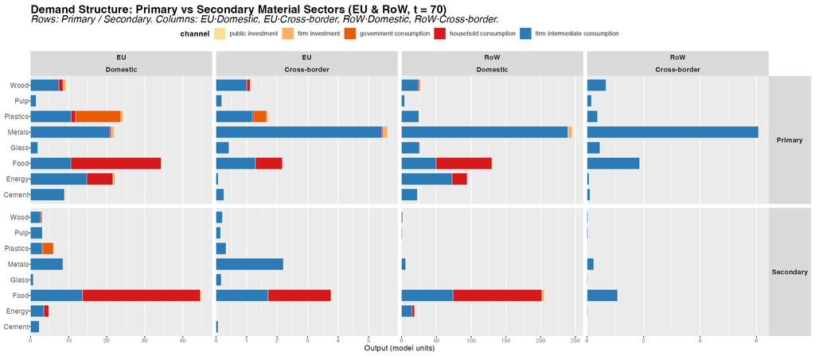

Figure 1: **Figure 1.** Gross output decomposition for primary and secondary material sectors across EU and RoW. Columns: EU Domestic, EU Cross-border, RoW Domestic, RoW Cross-border demand. Rows: Primary vs Secondary. Bars stacked by institutional demand channel.

Figure 1 decomposes gross output for all eight material pairs by institutional demand channel (household consumption, government consumption, firm investment, public investment, and firm intermediate consumption) across four regional flow dimensions: EU domestic production for EU demand, EU cross-border imports from RoW, RoW domestic production, and RoW cross-border exports to EU.

Four structural patterns are worth foregrounding for what they imply about the relative leverage of CE policy instruments across sectors. Industrial materials — cement, glass, metals, and pulp — are overwhelmingly activated through firm intermediate consumption, which accounts for 93–96% of EU gross output. Final demand channels are structurally marginal: demand-side instruments such as eco-labelling or green public procurement operate on a fraction of total material activation in these sectors, and cannot substitute for production-side instruments. Food stands at the opposite extreme: 65% of EU domestic food output serves household consumption, making it the one sector where a consumer-facing intervention engages the dominant demand channel directly. Energy occupies an intermediate position, with roughly two-thirds of total demand driven by industrial procurement of fossil-fuel electricity — a structural feature that makes consumer energy behaviour a secondary rather than primary lever for energy CE transitions. Plastics is the analytically exceptional case: while approximately 55% of output serves final demand, that component is dominated by government consumption rather than households, making circular public procurement the structurally primary demand-side instrument for this material, with implications that are explored in the scenario analysis below.

### EU Import Structure: Demand for RoW Goods

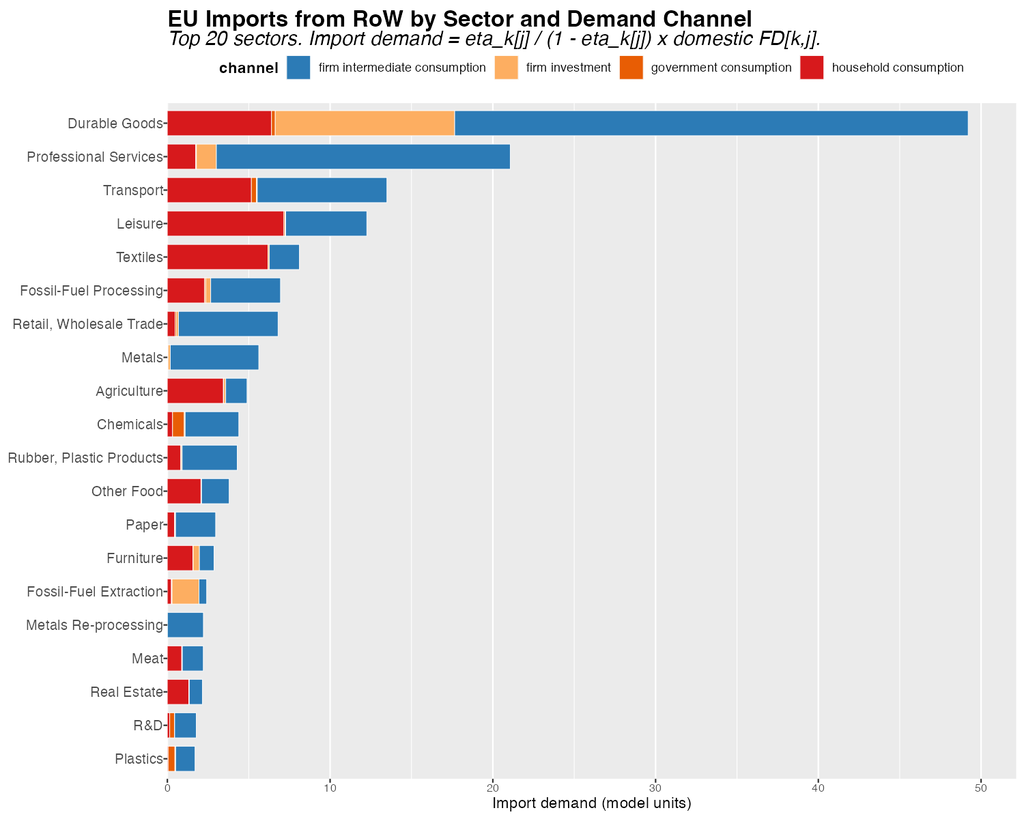

Figure 2: **Figure 2.** EU import demand from RoW decomposed by sector and institutional demand channel. Includes firm intermediate consumption, household consumption, government consumption, and firm investment. Top 20 sectors by total import demand.

Figure 2 maps the cross-border component of EU demand — imports from RoW — broken down by institutional channel, including both final demand channels (households, government, fixed investment) and firms’ circulating investment. Firm intermediate consumption dominates EU import demand across most high-import sectors. For energy and manufactured goods, the bulk of cross-border purchases are industrial inputs, not consumer goods, which implies that CE policies targeting intermediate production substitution have the largest potential to reduce import dependency alongside domestic primary material use. Fossil fuels and energy rank among the highest-import sectors, with a pronounced intermediate consumption component reflecting the EU’s structural dependence on imported fossil-fuel inputs for industrial production. Government and household consumption import shares are non-trivial for food and certain consumer goods, identifying specific channels where procurement policy and consumption-side interventions could reduce cross-border material footprints. Crucially, the ranking of sectors by total import demand directly anticipates which CE transitions will generate the largest trade balance improvements in the dynamic simulations: scenarios that reduce demand in high-import primary sectors will produce the largest improvements in the EU current account balance.

### CE Policy Portfolio Effectiveness

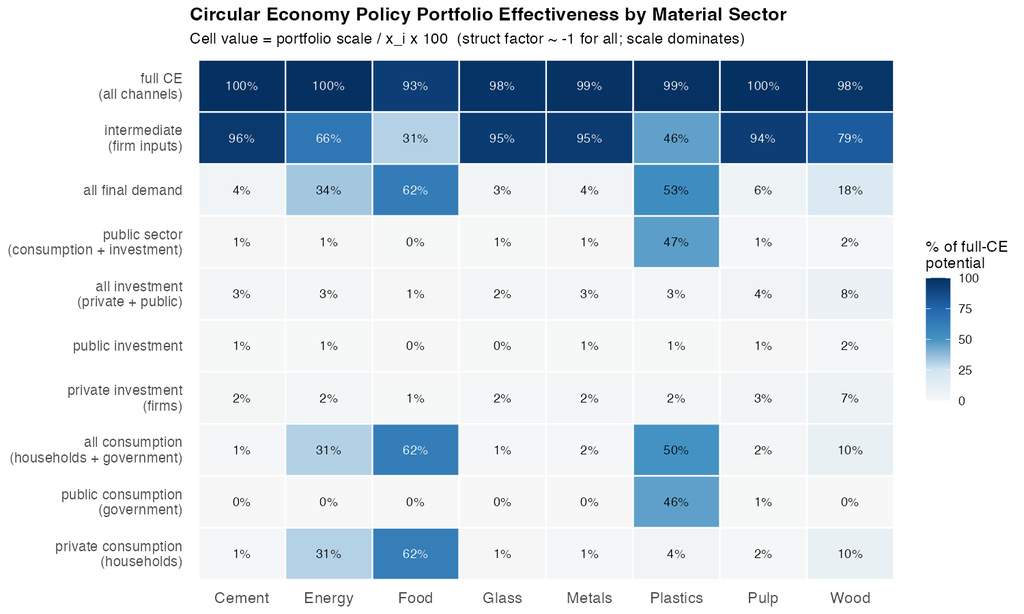

Figure 3: **Figure 3.** CE policy portfolio effectiveness by material sector. Cell values report the portfolio scale as a percentage of gross output x_i, which — given the structural factor (l_i2 − l_i1) ≈ −1 for all materials — equals the percentage of full-CE potential captured by that portfolio at substitution intensity ρ = 0.2.

### Full Supply-Chain Upstream Requirements (Leontief Decomposition)

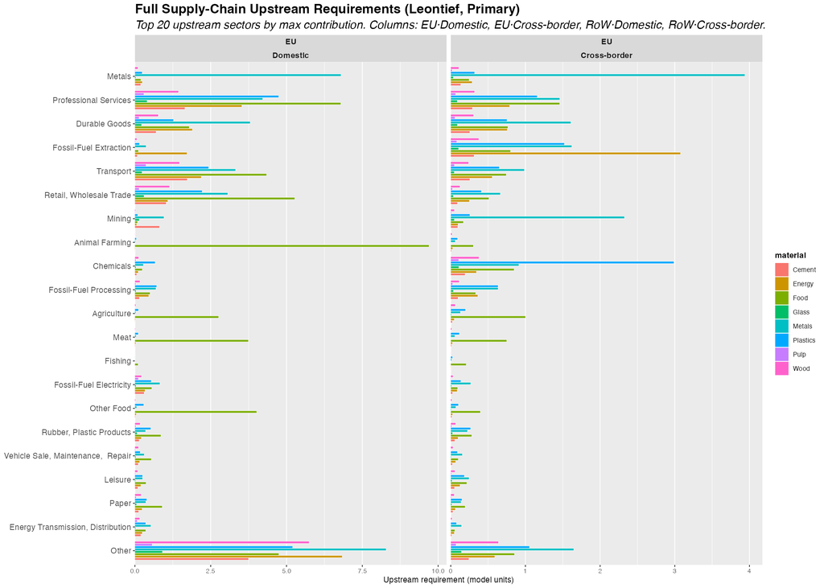

Figure 4: **Figure 4.** Full supply-chain upstream input requirements for primary material sectors. Column view of (L − I)[k,i] × x[i]: which sectors k are required as inputs, across all orders of IO interdependence, to sustain each material sector’s gross output. Top 20 upstream sectors by aggregate contribution. EU domestic and cross-border columns.

Figure 4 presents the column view of the Leontief upstream decomposition: $(L - I)_{ki} \cdot x_i$, showing which sectors $k$ are required as inputs — across all orders of IO interdependence — to sustain the gross output $x_i$ of each material sector $i$. This is the full supply-chain view, encompassing not just direct inputs but all indirect upstream requirements propagated through the IO system.

### Analytical First-Order Emission Impact

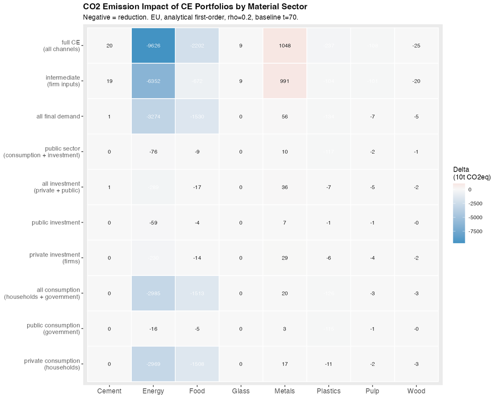

Figure 5: **Figure 5.** Analytical first-order CO2 emission impact (ΔCO2, 10t CO2eq) of CE portfolios by material sector and demand channel. Negative = reduction. Based on sector-level emission intensities at t = 70 and the Leontief output change formula. EU region, ρ = 0.2.

Figure 5 translates the portfolio scale and intensity structure into analytical first-order emission estimates. Carbon energy intermediate substitution generates by far the largest absolute emission reductions, reflecting both the dominant intermediate channel share (66%) and the 3.3:1 emission intensity differential between fossil and renewable electricity. Industrial materials (glass, cement, metals) show near-zero or slightly positive emission changes, consistent with the structural rebound findings for those sectors: secondary production pathways for these materials are not substantially less emission-intensive than primary pathways under current EU calibration, and in the case of metals, secondary production is more emission-intensive. These analytical estimates anticipate the dynamic simulation results quantitatively, and the correspondence between the two confirms that the first-order Leontief approximation captures the dominant mechanism even in the full dynamic model.

*These five structural measurements establish a clear pre-ordering of scenario outcomes. The portfolio heatmap identifies which channels carry leverage; the Leontief decomposition explains why certain substitutions generate emission rebounds; the import structure anticipates which scenarios improve the current account. The scenario simulations that follow confirm this pre-ordering in every case and trace the macroeconomic and distributional pathways through which these structural predictions materialise in the dynamic model.*

## Scenario Design

### Scenario Registry

**Table 1.** Scenario Registry. All scenarios use ρ = 0.2 except Construction scenarios (Sc5, Sc14) which use ρ = 0.05.

| # | Domain | Sector | Channel | Material | ρ |
| --- | --- | --- | --- | --- | --- |
| 1 | Final Demand | Household | Consumption | Food | 0.20 |
| 2 | Final Demand | Household | Consumption | Energy | 0.20 |
| 3 | Final Demand | Household | Consumption | Wood | 0.20 |
| 4 | Final Demand | Government | Consumption | Plastics | 0.20 |
| 5 | Final Demand | Firm | Fixed Investment | Construction | 0.05 |
| 6 | Final Demand | Firm | Fixed Investment | Metal | 0.20 |
| 7 | Intermediate Demand | Firm | Production | Wood | 0.20 |
| 8 | Intermediate Demand | Firm | Production | Pulp | 0.20 |
| 9 | Intermediate Demand | Firm | Production | Plastics | 0.20 |
| 10 | Intermediate Demand | Firm | Production | Metal | 0.20 |
| 11 | Intermediate Demand | Firm | Production | Glass | 0.20 |
| 12 | Intermediate Demand | Firm | Production | Cement | 0.20 |
| 13 | Intermediate Demand | Firm | Production | Energy | 0.20 |
| 14 | Intermediate Demand | Firm | Production | Construction | 0.05 |

Table 1 lists the 14 scenarios implemented in the model. Scenarios 1–6 operate through final demand — targeting specific institutional channels (household consumption, government procurement, or firm fixed investment) for eight material pairs. Scenarios 7–14 operate through intermediate production, adjusting the A-matrix coefficients that govern which material sectors firms use as inputs. Two scenarios target construction (Sc5, Sc14), which occupies a distinct structural position as the dominant intermediate user of cement, metals, glass, and wood simultaneously, and is parameterised at ρ = 0.05 to reflect imperfect substitutability between circular and conventional construction inputs. All other scenarios use ρ = 0.2. Policy shocks are activated at period $t^* = 70$ and the model runs for 100 periods total.

### Scenario Summary: Main Findings per Scenario

**Table 2.** Scenario summary: key simulation findings at Long Term (t + 20 relative to shock). FD = Final Demand, Int. = Intermediate Demand, HH = Household, Gov. = Government. All percentage changes relative to baseline.

[output not shown]

## Scenario Analysis and Discussion

### The Portfolio Scale Principle

The most robust finding across all 14 scenarios is that the rank ordering of outcomes is predicted by the absolute scale of the targeted demand channel, not by material-specific multiplier variation or sectoral intensity alone. The structural Leontief factor $(l_{12} - l_{11})$ is approximately $-1$ across all material sectors, meaning that primary-to-secondary substitution consistently contracts aggregate demand in proportion to channel size. What varies decisively across scenarios is the size of the demand portfolio the policy instrument engages. This generates a clear ranking.

**Household energy (Sc2)** produces strong emission and primary material savings ($Z_1$ $emis = -0.78\%$, $Z_1$ $x\_mat = -0.64\%$) disproportionate to its channel size (6.9 B EUR) because the 3.3:1 fossil-to-renewable intensity differential amplifies the scale effect on both emission and primary energy extraction.

**Government plastics (Sc4)** has disproportionate leverage among FD scenarios because the government procurement channel (11.9 B EUR) rivals the intermediate channel in absolute scale — unique among all materials. However, the material effect is ambiguous: EU total material use barely changes while primary extraction falls only $-0.04\%$, reflecting small primary–secondary intensity gaps for plastics.

**Metals production (Sc10)** produces the largest total material savings ($Z_1$ $mat = -0.76\%$ LT) because intermediate metal demand (20.9 B EUR) is the largest single intermediate material flow in the scenario set. The A-matrix row-sum of secondary metals (0.238) is less than half that of primary metals (0.545), amplifying material throughput reductions across the supply chain.

The simulation ranking therefore validates the demand channel decomposition: before running the model, relative outcome magnitudes can be predicted from channel scale × intensity differential with reasonable accuracy.

### The CE Trilemma

The cross-cutting finding is a structural trilemma: ecological improvement trades off against macroeconomic stability and distributional equity in the intermediate production scenarios, while the construction scenarios produce a second, ecological-internal tension between material savings and emission rebound.

**Scenario 10 (Metals)** is the most analytically anomalous outcome. It is the only production scenario showing expansionary macroeconomic effects ($Z_1$ $go = +0.04\%$, $n = +0.03\%$ LT), driven by the lower A-matrix row-sum of secondary metals (0.238 vs 0.545): substituting secondary for primary frees EU intermediate resources economy-wide and generates a competitive dividend. Simultaneously, emissions increase (+0.27% LT) — the clearest structural rebound in the set. The mechanism is precisely identified: secondary metal production (EAF scrap-based steel) is more electricity-intensive upstream than primary production (blast furnace), and the high fossil emission intensity amplifies this into an EU emission increase even as material throughput falls strongly ($Z_1$ $mat = -0.76\%$). Metals CE satisfies the economic arm of the trilemma while failing the ecological arm and requires complementary electricity decarbonisation.

**Scenario 13 (Energy)** represents maximum leverage and maximum asymmetry simultaneously. Ecological gains are the largest in the set ($emis = -1.56\%$, $x\_mat = -1.27\%$ LT), and the current account improvement (+1.81%) reflects reduced EU fossil import dependency. But the scenario is distributionally regressive (wage share $-0.08\%$, profit share $+0.14\%$) and produces the largest cross-border burdens on RoW energy exporters ($Z_2$ $b\_s$ rises, $Z_2$ $n = -0.01\%$). The land use implication is notable: despite saving the most emissions, EU land use increases slightly (+0.16% LT) because renewable electricity infrastructure (wind and solar) requires substantially more land per unit of output than centralised fossil power plants. EU energy CE is the highest-leverage domestic CE intervention while simultaneously the most asymmetric in its international consequences.

### Cross-Border Transmission: Material Flows and RoW Consequences

A key contribution of the MRIO-SFC framework is tracing bilateral demand flows between EU ($Z_1$) and RoW ($Z_2$), making the cross-border consequences of CE policy directly visible.

**Table 3.** RoW long-term % deviation from baseline — material use. Values rounded to 2 decimal places.

| Variable | Sc1 | Sc2 | Sc3 | Sc4 | Sc5 | Sc6 | Sc7 | Sc8 | Sc9 | Sc10 | Sc11 | Sc12 | Sc13 | Sc14 |
| --- | --- | --- | --- | --- | --- | --- | --- | --- | --- | --- | --- | --- | --- | --- |
| RoW total material use (%, LT) | +0.01 | -0.00 | 0 | +0.01 | -0.05 | 0 | 0 | 0 | +0.01 | -0.15 | 0 | 0 | -0.00 | -0.02 |
| RoW primary material extraction (%, LT) | 0 | -0.03 | 0 | 0 | 0 | 0 | 0 | 0 | 0 | -0.10 | 0 | 0 | -0.05 | 0 |

### Ecological Pressure Divergence: Land and Water

A secondary but analytically important finding is that emissions, land use, and water use diverge across scenarios, driven by different sector-specific intensity coefficients. Scenario 1 (Food/Meat) produces emission savings ($-0.42\%$) but water use increases (+0.68% EU), because other food products (the secondary sector) are more water-intensive per unit of output than the primary meat sector. Scenario 7 (Wood Int) delivers the largest land saving in the entire scenario set (EU land $= -2.30\%$ LT) from a scenario with near-zero emission effect ($-0.01\%$): forest-sector restructuring releases land without changing fossil energy consumption, and the land–emission decoupling is strongest here. Scenario 13 (Energy Int) saves the most emissions ($-1.56\%$) but land use increases (+0.16%), because renewable energy infrastructure requires more land per MWh than fossil plants. Construction scenarios (Sc5, Sc14) show an emissions rebound (+5.19%, +2.15%) but land and water improve, because the circular reallocation reduces primary material and land extraction while worsening the atmospheric footprint.

These divergences reinforce that no single ecological indicator is sufficient for CE policy evaluation. Wood-sector restructuring is primarily a land-use intervention; energy-sector restructuring is primarily a climate intervention; food-sector restructuring is primarily an atmospheric and land intervention that worsens freshwater pressure.

## Policy Implications

Four policy implications follow directly from the simulation evidence.

First, **production restructuring requires macroeconomic stabilisation**. Production scenarios consistently contract aggregate demand modestly, reduce wage shares, and expand profit shares. CE transitions in the production regime cannot be treated as costless structural adjustments — they require active macroeconomic management and labour market support.

Second, **final-demand reallocation is primary for specific channels**. For most material sectors where intermediate demand dominates (metals, wood, glass, cement), FD instruments engage structurally secondary channels and cannot substitute for A-matrix restructuring. However, for construction (investment-dominated), food (household-dominated), and plastics (government-procurement-dominated), FD instruments engage the primary demand channel directly and are first-order CE instruments in their own right.

Third, **energy is the highest-leverage CE instrument, but land use is its shadow cost**. Scenario 13 dominates all other production scenarios in both emission reduction ($-1.56\%$) and primary material extraction reduction ($-1.27\%$). However, renewable energy infrastructure requires substantially more land per unit of output than fossil plants, meaning that scaling this transition without land-use planning creates a new ecological trade-off that the emissions indicator does not capture.

Fourth, **metals CE requires electricity decarbonisation as a complement, and its cross-border material dividend is real but regressive**. Without simultaneous electricity decarbonisation, secondary metal production amplifies upstream emissions through the fossil energy link. With decarbonisation, Metals CE could simultaneously expand EU output, reduce global material throughput (including $-0.15\%$ in RoW), and reduce emissions — making it uniquely triple-positive. The current calibration shows only the first and second arm; the third requires a policy complement.

## Scenario Comparison Figures

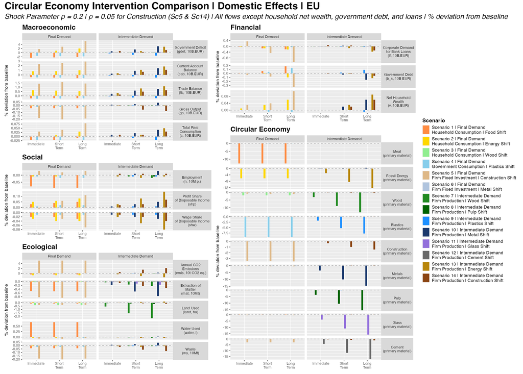

Figure 6: **Figure 6.** Circular Economy Intervention Comparison — Domestic Effects (EU). All 14 scenarios across three time horizons: Immediate (t+1), Short-Term (t+7), and Long-Term (t+20). Left column: Macroeconomic, Social, Ecological variables. Right column: Financial and CE sector primary material outputs. % deviation from baseline.

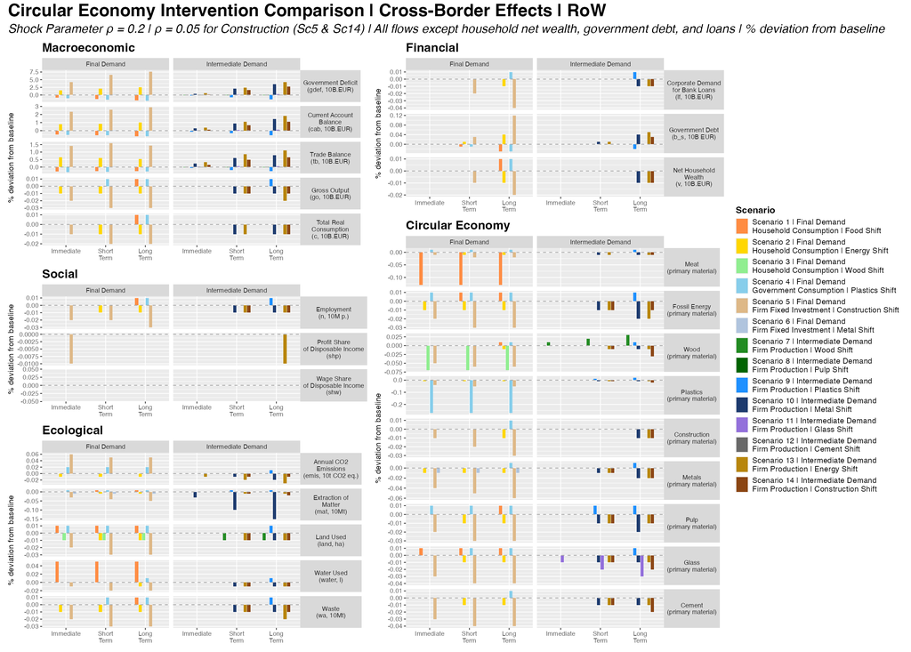

Figure 7: **Figure 7.** Circular Economy Intervention Comparison — Cross-Border Effects (RoW). Same layout as Figure 6. Captures the transnational transmission of EU CE policy to the Rest of World.

## Conclusions

These findings carry implications for how CE policy is conceptualised and analysed. Single-region input-output frameworks cannot capture the cross-border transmission patterns identified here, and any CE evaluation conducted at the national level risks attributing improvements to domestic efficiency while missing the displacement of extraction, emissions, and employment burdens onto partner economies. At the same time, the results challenge the assumption — common in single-material and partial-equilibrium analyses — that circular production transitions are costless structural adjustments. The employment contractions, wage share compressions, and distributional regressions documented in the intermediate production scenarios are modest in magnitude but consistent in direction. They signal a policy requirement that cannot be resolved by circular economy instruments alone: production-side CE transitions need to be accompanied by active macroeconomic management and labour market support to avoid generating regressive distributional outcomes alongside ecological improvements. The complementarity between CE and decarbonisation is especially visible in the metals case: under a decarbonised electricity grid, metals CE would simultaneously reduce material throughput, expand economic output, and cut emissions — making it uniquely triple-positive — whereas under current fossil energy conditions it satisfies the economic arm of the trilemma while failing the ecological arm.

Several limitations of the current analysis point to productive directions for further work. The model is calibrated to 2011 EXIOBASE data, and the emission intensity of secondary metal production and secondary construction may have changed as electricity grids decarbonise and circular infrastructure matures. Future analyses incorporating dynamic calibration for electricity decarbonisation and technology-learning pathways would substantially strengthen the policy relevance of these findings. More broadly, the model’s treatment of the Rest of World as a single undifferentiated aggregate obscures the differential impacts on specific fossil-fuel exporting economies, low-income countries dependent on primary commodity exports, and emerging economies at different stages of their own CE transitions. Disaggregating the RoW aggregate is a priority for future work if the framework is to serve its intended purpose as a tool for evaluating the just dimensions of CE policy in an interconnected global economy.

## References

Althouse, J., Guarini, G., Porcile, G. (2020). Ecological macroeconomics in the open economy: Sustainability, unequal exchange and policy coordination in a center–periphery model. *Ecological Economics*, 172, 106628.

Arranz, C.F.A., Arroyabe, M.F., Demirel, P., Kesidou, E., Panwar, R., Pinkse, J., 2026. Reconciling circular economy and net zero: Firm capabilities to resolve sustainability tensions. *British Journal of Management* 00, e70061.

Campiglio, E., Dafermos, Y., Monnin, P., Ryan-Collins, J., Schotten, G., Tanaka, M., 2018. Climate change challenges for central banks and financial regulators. *Nature Climate Change* 8 (6), 462–468.

Di Domenico, L., Barbieri Góes, M. C., and Gallo, E. (2024). Distribution, capital intensity and public debt-to-GDP ratio: an input output-stock flow consistent model. *Economia Politica*, 41(2), 395-416.

Dorninger, C., Hornborg, A., Abson, D. J., von Wehrden, H., Schaffartzik, A., Giljum, S., Engler, J.-O., Feller, R. L., Hubacek, K., & Wieland, H. (2021). Global patterns of ecologically unequal exchange: Implications for sustainability in the 21st century. *Ecological Economics*, 179, 106824.

Fevereiro, J.B.R.T. and Lowe, B.H. (2025) Macroeconomic implications for the Global South of a green transition in the Global North. *Ecological Economics*, 237. 108691.

Geissdoerfer, M., Savaget, P., Bocken, N.M.P., Hultink, E.J., 2017. The circular economy – A new sustainability paradigm? *Journal of Cleaner Production* 143, 757–768.

Gräbner-Radkowitsch, C., and Strunk, B. (2023). Degrowth and the Global South: The twin problem of global dependencies. *Ecological Economics*, 213, 107946.

Hickel, J., 2020. Quantifying national responsibility for climate breakdown: An equality-based attribution approach for carbon dioxide emissions in excess of the planetary boundary. *The Lancet Planetary Health* 4 (9), e399–e404.

Hickel, J., Dorninger, C., Wieland, H., Suwandi, I., 2022. Imperialist appropriation in the world economy: Drain from the Global South through unequal exchange, 1990–2015. *Global Environmental Change* 73, 102467.

Hornborg, A., 2009. Zero-sum world: Challenges in conceptualizing environmental load displacement and ecologically unequal exchange in the world-system. *International Journal of Comparative Sociology* 50 (3–4), 237–262.

Jackson, T., Victor, P.A., 2019. Unraveling the claims for (and against) green growth. *Science* 366 (6468), 950–951.

Jackson, A., and Jackson, T. (2025). Macroeconomic, sectoral and financial dynamics in energy transitions: A stock-flow consistent, input-output approach. *Ecological Economics*, 230, 108507.

Kirchherr, J., Reike, D., Hekkert, M., 2017. Conceptualizing the circular economy: An analysis of 114 definitions. *Resources, Conservation and Recycling* 127, 221–232.

Korhonen, J., Honkasalo, A., Seppälä, J., 2018. Circular economy: The concept and its limitations. *Ecological Economics*, 143, 37–46.

Lenzen, M., Moran, D., Kanemoto, K., Geschke, A., 2012. Mapping the structure of the world economy. *Environmental Science & Technology* 46 (15), 8374–8381.

Pettena, M. and Raberto, M. (2025). Energy transition and structural change: A calibrated Stock-Flow Consistent Input-Output model. *Structural Change and Economic Dynamics*, online.

Pollitt, H., Mercure, J.-F., 2018. The role of money and the financial sector in energy-economy models used for assessing climate and energy policy. *Climate Policy* 18 (2), 184–197.

Svartzman, R., and Althouse, J. (2020). Greening the international monetary system? Not without addressing the political ecology of global imbalances. *Review of International Political Economy*.

Thomsen, S. F., Raza, H., and Byrialsen, M. R. (2025). An assessment of carbon taxation policies: The case of Denmark. *Ecological Economics*, 238, 108741.

Veronese Passarella, M. (2023). Technical change and the monetary circuit: an input-output stock-flow consistent dynamic model. *Quaderni del Dipartimento di Economia Politica e Statistica - Università di Siena*, n. 903.

Veronese Passarella, M. (2025). Destabilizing a Stable Economy: Minsky Meets Graziani’s Monetary Circuit. *International Journal of Political Economy*, 54 (3): 338-355.

## Appendix 3: Calibration

The target values of the calibration are presented in Table A1 below.

**Table A1.** Calibration target values (10 billion EUR). Source: authors’ own elaboration based on EXIOBASE 3.

| Region | Consumption | Investment | Gov. Spending | Final Exports | Final Imports | GDP | Gross Output |
| --- | --- | --- | --- | --- | --- | --- | --- |
| EU (Z1) | 626.32 | 245.77 | 239.46 | 102.78 | 66.36 | 1130.67 | 2153.60 |
| RoW (Z2) | 2370.71 | 1135.84 | 675.33 | 66.36 | 102.78 | 4162.75 | 8424.52 |

## Footnotes

[^1]: The full description of the equations of the model is presented in Appendix 1.
[^2]: A complete list of the sectors is provided in Appendix 2.
[^3]: For example, following post-Keynesian theory, a constraint is introduced to ensure parameter values for the propensity to consume out of wages is higher than out of profit and, in turn, out of wealth.